# E) Time to churn

Research Question: **“Which customer segments and engagement levers (coupons, campaigns, spend intensity) meaningfully extend household survival, so we know whom to target and which promotional tactics actually drive profitable retention?”**

For this, we investigate:

- Time until churn → survival analysis (“Customer survival")
- Understanding how factors affect churn timing
- “Campaigns and coupon tactics” as concrete explanatory variables (marketing actions)

## Learning references

We went through the Complete Journey data dictionary plus the Lecture 10 slides. Lecture 10 explains Kaplan Meier estimators, the log rank test, and the Cox proportional hazards model so we refer to those ideas whenever we interpret retention patterns.

## Data preparation approach

- build per household purchase history with spend, discount share, product breadth, and trip frequency features
- set a four week buffer before the end of the observation window to avoid labeling late shoppers as churned without evidence
- merge coupon redemptions and campaign assignments so we can compare engagement strategies
- keep the demographic classes that were also used inside the customer value map folder which lets us cross reference the same segments across workstreams

```python
from pathlib import Path

import matplotlib.pyplot as plt
import numpy as np
import pandas as pd
from lifelines.statistics import multivariate_logrank_test

from functions.data_prep import compile_survival_dataset, load_compiled_dataset
from functions.survival_utils import (
    fit_cox_model,
    fit_kaplan_meier_by_group,
    get_segment_summary,
    run_logrank_test,
)
from functions.plotting import plot_km_results, plot_cumulative_hazard

plt.style.use('seaborn-v0_8')
PROJECT_DIR = Path.cwd()
OUTPUT_DIR = PROJECT_DIR / 'outputs'
OUTPUT_DIR.mkdir(exist_ok=True)
pd.set_option('display.max_columns', 40)
```

## Build the survival dataset

We recreate the modeling table inside this notebook. The helper imposes the four week censoring buffer described above and writes the file into the data folder for transparency.

```python
dataset, dataset_path = compile_survival_dataset(buffer_weeks=4)
print(f'Dataset shape: {dataset.shape} saved to {dataset_path}')
dataset.head()
```

```
Dataset shape: (2500, 44) saved to /Users/arturrenzenbrink/github/ie_ca/code/e_time_to_churn/data/time_to_churn_dataset.csv
```

|  | household_key | first_day | last_day | first_week | last_week | num_trips | num_products | total_units | total_spend | retailer_disc | coupon_disc | coupon_match_disc | num_stores | tenure_days | tenure_weeks | avg_trip_value | unit_price | loyalty_discount_share | retailer_discount_share | trip_frequency_per_week | ... | coupons_redeemed | unique_coupons | coupon_campaigns | first_coupon_day | last_coupon_day | coupon_active_span | campaign_touchpoints | unique_campaigns | … |
| --- | --- | --- | --- | --- | --- | --- | --- | --- | --- | --- | --- | --- | --- | --- | --- | --- | --- | --- | --- | --- | --- | --- | --- | --- | --- | --- | --- | --- | --- | --- |
| 0 | 1 | 51 | 706 | 8 | 102 | 86 | 677 | 1997 | 4330.16 | -697.04 | -80.56 | -26.15 | 2 | 655 | 94 | 50.350698 | 2.168332 | -0.024643 | -0.160973 | 0.914894 | ... | 5.0 | 5.0 | 2.0 | 421.0 | 597.0 | 176.0 | 8.0 | 8.0 | … |
| 1 | 2 | 103 | 668 | 15 | 96 | 45 | 546 | 834 | 1954.34 | -334.99 | -9.00 | 0.00 | 5 | 565 | 81 | 43.429778 | 2.343333 | -0.004605 | -0.171408 | 0.555556 | ... | 0.0 | 0.0 | 0.0 | NaN | NaN | 0.0 | 1.0 | 1.0 | … |
| 2 | 3 | 113 | 703 | 17 | 101 | 47 | 516 | 8540 | 2653.21 | -675.16 | -61.19 | -19.80 | 3 | 590 | 84 | 56.451277 | 0.310680 | -0.030525 | -0.254469 | 0.559524 | ... | 0.0 | 0.0 | 0.0 | NaN | NaN | 0.0 | 3.0 | 3.0 | … |
| 3 | 4 | 104 | 627 | 16 | 90 | 30 | 164 | 382 | 1200.11 | -115.65 | -2.50 | 0.00 | 6 | 523 | 74 | 40.003667 | 3.141649 | -0.002083 | -0.096366 | 0.405405 | ... | 0.0 | 0.0 | 0.0 | NaN | NaN | 0.0 | 1.0 | 1.0 | … |
| 4 | 5 | 85 | 703 | 13 | 101 | 40 | 199 | 245 | 779.06 | -118.33 | 0.00 | 0.00 | 3 | 618 | 88 | 19.476500 | 3.179837 | 0.000000 | -0.151888 | 0.454545 | ... | 0.0 | 0.0 | 0.0 | NaN | NaN | 0.0 | 0.0 | 0.0 | … |

5 rows × 44 columns

Takeaway: We now have all 2500 households with engineered purchase, coupon, and campaign features plus the buffered survival targets stored at data/time_to_churn_dataset.csv.

```python
overall_summary = pd.Series({
    'households': len(dataset),
    'event_rate': dataset['event_observed'].mean(),
    'median_duration_weeks': dataset['duration_weeks'].median(),
    'avg_duration_weeks': dataset['duration_weeks'].mean(),
    'coupon_penetration': dataset['coupon_user_flag'].mean(),
    'campaign_reach': dataset['campaign_reached_flag'].mean(),
})
display(overall_summary.to_frame('value'))
```

|  | value |
| --- | --- |
| households | 2500.000000 |
| event_rate | 0.195200 |
| median_duration_weeks | 86.714286 |
| avg_duration_weeks | 86.001657 |
| coupon_penetration | 0.173600 |
| campaign_reach | 0.633600 |

```python
# make a formatted version for display
formatted_summary = overall_summary.copy()

formatted_summary['households'] = int(formatted_summary['households'])
formatted_summary = formatted_summary.round(2)

print("\nFormatted Summary:")
display(formatted_summary.to_frame('value'))
```

```
Formatted Summary:
```

|  | value |
| --- | --- |
| households | 2500.00 |
| event_rate | 0.20 |
| median_duration_weeks | 86.71 |
| avg_duration_weeks | 86.00 |
| coupon_penetration | 0.17 |
| campaign_reach | 0.63 |

```python
numeric_cols = [
    'duration_weeks',
    'num_trips',
    'total_spend',
    'avg_trip_value',
    'trip_frequency_per_week',
    'unique_campaigns',
    'coupons_redeemed',
]
dataset[numeric_cols].describe()
```

|  | duration_weeks | num_trips | total_spend | avg_trip_value | trip_frequency_per_week | unique_campaigns | coupons_redeemed |
| --- | --- | --- | --- | --- | --- | --- | --- |
| count | 2500.000000 | 2500.000000 | 2500.000000 | 2500.000000 | 2497.000000 | 2500.000000 | 2500.000000 |
| mean | 86.001657 | 110.593600 | 3222.985232 | 31.620757 | 1.227128 | 2.883200 | 0.927200 |
| std | 9.950074 | 115.669368 | 3349.026076 | 19.054944 | 1.261232 | 3.238418 | 3.231296 |
| min | 0.142857 | 1.000000 | 8.170000 | 2.387500 | 0.023810 | 0.000000 | 0.000000 |
| 25% | 82.857143 | 39.000000 | 970.740000 | 18.328784 | 0.438202 | 0.000000 | 0.000000 |
| 50% | 86.714286 | 79.000000 | 2157.750000 | 27.416887 | 0.875000 | 2.000000 | 0.000000 |
| 75% | 91.571429 | 142.250000 | 4413.320000 | 40.546201 | 1.568182 | 5.000000 | 0.000000 |
| max | 97.428571 | 1300.000000 | 38319.790000 | 165.829310 | 14.444444 | 17.000000 | 35.000000 |

Analysis takeaway: The median shopper makes 79 trips and spends roughly 2160 dollars over the horizon while a quarter of households receive five or more campaigns. Coupon redemptions are highly skewed with most households not redeeming any offer which is typical in retail datasets.

## Coupon engagement effect

We now compare the survival curves of coupon redeemers versus non redeemers following the Kaplan Meier estimator from Lecture 10.

The underlying research question is: “Do households that redeem at least one coupon exhibit longer survival than those that never redeem?”

```python
coupon_summary = get_segment_summary(
    dataset,
    group_col='coupon_user_flag',
    duration_col='duration_weeks',
    event_col='event_observed',
)
stat, pvalue = run_logrank_test(
    dataset,
    group_col='coupon_user_flag',
    duration_col='duration_weeks',
    event_col='event_observed',
    group_a=1,
    group_b=0,
)
display(coupon_summary)
print(f'Log rank chi2={stat:.2f} p-value={pvalue:.2e}')
```

|  | coupon_user_flag | customers | median_tenure | pct_churned |
| --- | --- | --- | --- | --- |
| 0 | 0 | 2066 | 86.6 | 0.224 |
| 1 | 1 | 434 | 87.4 | 0.058 |

```
Log rank chi2=58.86 p-value=1.70e-14
```

Analysis takeaway: Coupon redeemers have a median tenure of roughly 87 and one half weeks with only about 6% churn observed vs. about 22% percent for households that never redeem. The log rank test strongly rejects equality across the groups (as the small p value suggests strong evidence that the survival curves differ significantly) so coupon redeemers have a longer survival and are less likely to churn compared to non-redeemers. Even though median tenure is similar (since most customers haven’t churned yet), the event rate difference and p-value show coupon engagement is strongly associated with customer retention.

```
Saved plot to /Users/arturrenzenbrink/github/ie_ca/code/e_time_to_churn/outputs/km_coupon_flag.png
```

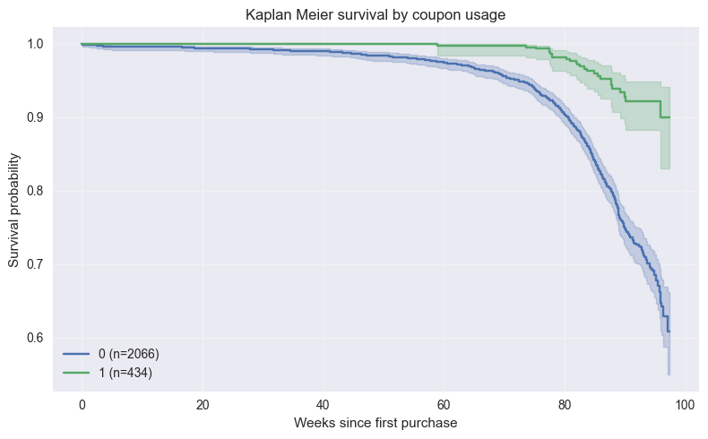

```python
km_coupon = fit_kaplan_meier_by_group(
    dataset,
    duration_col='duration_weeks',
    event_col='event_observed',
    group_col='coupon_user_flag',
)
fig, ax = plt.subplots(figsize=(8, 5))
plot_km_results(km_coupon, title='Kaplan Meier survival by coupon usage', ax=ax)
fig_path = OUTPUT_DIR / 'km_coupon_flag.png'
fig.tight_layout()
fig.savefig(fig_path, dpi=150)
print(f'Saved plot to {fig_path}')
plt.show()
plt.close(fig)
```

Early in the customer lifecycle, survival probabilities are more similar across groups, as both new households tend to remain active shortly after joining. Over time, however, coupon redeemers show consistently higher retention, which suggests that coupon redemptions exerts a long-term loyalty effect rather than an immediate one.

```
Saved plot to /Users/arturrenzenbrink/github/ie_ca/code/e_time_to_churn/outputs/km_coupon_hazard.png
```

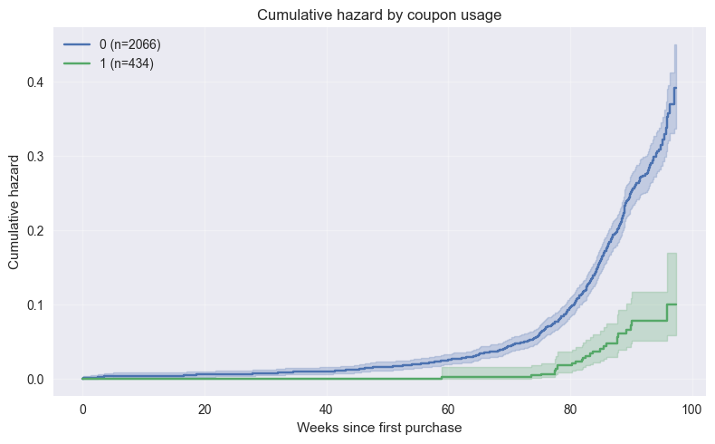

```python
fig, ax = plt.subplots(figsize=(8, 5))
plot_cumulative_hazard(km_coupon, title='Cumulative hazard by coupon usage', ax=ax)
tech_path = OUTPUT_DIR / 'km_coupon_hazard.png'
fig.tight_layout()
fig.savefig(tech_path, dpi=150)
print(f'Saved plot to {tech_path}')
plt.show()
plt.close(fig)
```

## Campaign reach effect

Next we test whether being assigned to any campaign is associated with longer survival.

The underlying Research Question is: “Do households that are touched by at least one campaign exhibit longer survival than those who never see a campaign?”

```python
campaign_summary = get_segment_summary(
    dataset,
    group_col='campaign_reached_flag',
    duration_col='duration_weeks',
    event_col='event_observed',
)
stat, pvalue = run_logrank_test(
    dataset,
    group_col='campaign_reached_flag',
    duration_col='duration_weeks',
    event_col='event_observed',
    group_a=1,
    group_b=0,
)
display(campaign_summary)
print(f'Log rank chi2={stat:.2f} p-value={pvalue:.2e}')
```

|  | campaign_reached_flag | customers | median_tenure | pct_churned |
| --- | --- | --- | --- | --- |
| 0 | 0 | 916 | 85.4 | 0.357 |
| 1 | 1 | 1584 | 87.6 | 0.102 |

```
Log rank chi2=275.71 p-value=6.47e-62
```

Analysis takeaway: Households that saw a campaign (they had at least 1 campaign touchpoint) show a median tenure of about 88 weeks with only 10% churn observed vs.36% percent for untouched households. The large and highly significant log-rank statistic (χ² = 275.7, p < 0.001) confirms that campaign exposure is strongly associated with longer survival and lower churn, which means that marketing campaigns have a clear retention impact - consistent campaign exposure strengthens customer engagement and loyalty over time.

```
Saved plot to /Users/arturrenzenbrink/github/ie_ca/code/e_time_to_churn/outputs/km_campaign_flag.png
```

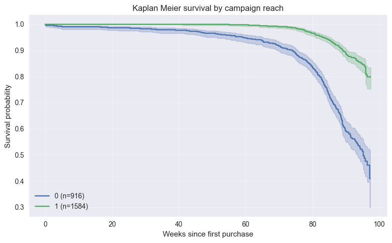

```python
km_campaign = fit_kaplan_meier_by_group(
    dataset,
    duration_col='duration_weeks',
    event_col='event_observed',
    group_col='campaign_reached_flag',
)
fig, ax = plt.subplots(figsize=(8, 5))
plot_km_results(km_campaign, title='Kaplan Meier survival by campaign reach', ax=ax)
camp_path = OUTPUT_DIR / 'km_campaign_flag.png'
fig.tight_layout()
fig.savefig(camp_path, dpi=150)
print(f'Saved plot to {camp_path}')
plt.show()
plt.close(fig)
```

## Demographic survival differences

We keep the demo_class_1 segments that also appear in the customer value map work. We test whether tenure differs across the six demo_class_1 age segments by running a multivariate log-rank test, which evaluates all groups simultaneously instead of doing fifteen pairwise log-rank comparisons, and summarizing each cohort’s median tenure and churn rate. The underlying Research Question is “Do customer survival times differ meaningfully across the six demo_class_1 (age) segments, indicating that retention performance varies by demographic cohort?”

```python
demo_summary = get_segment_summary(
    dataset,
    group_col='demo_class_1',
    duration_col='duration_weeks',
    event_col='event_observed',
)
display(demo_summary)
logrank = multivariate_logrank_test(
    dataset['duration_weeks'],
    dataset['demo_class_1'],
    dataset['event_observed'],
)
print(f'Multivariate log rank chi2={logrank.test_statistic:.2f} p-value={logrank.p_value:.2e}')
```

|  | demo_class_1 | customers | median_tenure | pct_churned |
| --- | --- | --- | --- | --- |
| 0 | Age Group1 | 46 | 86.9 | 0.087 |
| 1 | Age Group2 | 142 | 87.9 | 0.028 |
| 2 | Age Group3 | 194 | 87.9 | 0.052 |
| 3 | Age Group4 | 288 | 87.0 | 0.052 |
| 4 | Age Group5 | 59 | 87.4 | 0.051 |
| 5 | Age Group6 | 72 | 86.7 | 0.111 |

```
Multivariate log rank chi2=9.00 p-value=1.73e-01
```

Analysis takeaway:

Age Group 2 and Age Group 5 show the highest survival, while Age Group 6 is more at risk. However, the multivariate log-rank test (χ² = 9.00, p = 0.17) indicates that these differences are not statistically significant (since 0.173 > 0.05). This suggests that while some age clusters appear slightly more stable, overall retention patterns are broadly similar across age groups.

From a business standpoint, this implies that age alone may not be a strong driver of churn, and campaign or coupon engagement could be more influential retention levers. Nonetheless, targeted messaging to the higher-risk Age Group 6 segment might still be valuable.

```
Saved plot to /Users/arturrenzenbrink/github/ie_ca/code/e_time_to_churn/outputs/km_demo_class1.png
```

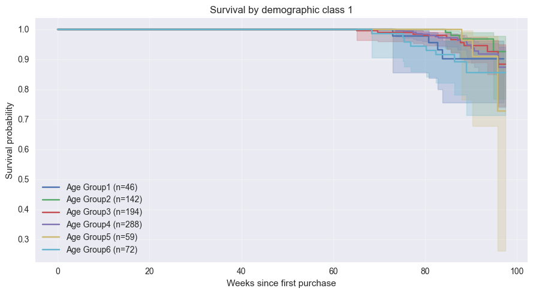

```python
km_demo = fit_kaplan_meier_by_group(
    dataset,
    duration_col='duration_weeks',
    event_col='event_observed',
    group_col='demo_class_1',
    min_group_size=40,
)
fig, ax = plt.subplots(figsize=(9, 5))
plot_km_results(km_demo, title='Survival by demographic class 1', ax=ax)
demo_path = OUTPUT_DIR / 'km_demo_class1.png'
fig.tight_layout()
fig.savefig(demo_path, dpi=150)
print(f'Saved plot to {demo_path}')
plt.show()
plt.close(fig)
```

Plot takeaway:Age Group 2 keeps more than 96 % of households active after ninety weeks while Age Group 6 drops closer to 85% - Although the overall differences across age segments are modest, this pattern suggests that younger or mid-aged cohorts (e.g., Group 2) are slightly more resilient, whereas older groups may require additional retention efforts. Campaign resources could therefore be prioritized toward higher-risk age clusters to balance churn performance.

## Cox proportional hazards model

We move to the multivariate Cox model as we want to control for other variables (spending) in addition to age, to check whether coupon and campaign levers remain predictive after controlling for both of them (spending and demographics).

The underlying Research Question for this section is “After controlling for core behavioral metrics (trips, spend) and demographics, do campaign touches and coupon engagement still reduce churn hazard, and which covariates remain significant predictors of customer survival?”

```python
cox_df = dataset.copy()
cox_df['log_total_spend'] = np.log1p(cox_df['total_spend'])
cox_df['log_trips'] = np.log1p(cox_df['num_trips'])
cox_df['log_unique_campaigns'] = np.log1p(cox_df['unique_campaigns'])
cox_df['trip_frequency_per_week'] = cox_df['trip_frequency_per_week'].fillna(0)
cox_df['avg_trip_value'] = cox_df['avg_trip_value'].fillna(cox_df['avg_trip_value'].median())
cox_df['coupon_share'] = cox_df['loyalty_discount_share'].fillna(0)
demo_dummies = pd.get_dummies(cox_df['demo_class_1'], prefix='demo1', drop_first=True)
cox_df = pd.concat([cox_df, demo_dummies], axis=1)

covariates = [
    'coupon_user_flag',
    'campaign_reached_flag',
    'log_unique_campaigns',
    'coupons_redeemed',
    'trip_frequency_per_week',
    'avg_trip_value',
    'log_total_spend',
    'coupon_share',
    'log_trips',
    *demo_dummies.columns.tolist(),
]

cox = fit_cox_model(
    cox_df,
    duration_col='duration_weeks',
    event_col='event_observed',
    covariates=covariates,
    penalizer=0.05,
)
cox_summary = cox.summary[['coef', 'exp(coef)', 'p']].sort_values('exp(coef)')
display(cox_summary)
print(f'Concordance index={cox.concordance_index_:.3f}')
```

| covariate | coef | exp(coef) | p |
| --- | --- | --- | --- |
| log_trips | -0.554478 | 0.574372 | 1.462875e-16 |
| demo1_Age Group2 | -0.550392 | 0.576724 | 4.015386e-02 |
| log_total_spend | -0.407940 | 0.665019 | 1.003397e-12 |
| demo1_Age Group3 | -0.301454 | 0.739742 | 1.745004e-01 |
| demo1_Age Group4 | -0.261749 | 0.769704 | 1.624324e-01 |
| demo1_Age Group5 | -0.240011 | 0.786620 | 5.422286e-01 |
| coupon_user_flag | -0.073886 | 0.928777 | 6.631117e-01 |
| log_unique_campaigns | -0.067933 | 0.934324 | 3.981403e-01 |
| coupons_redeemed | -0.009348 | 0.990696 | 6.663464e-01 |
| avg_trip_value | 0.005690 | 1.005706 | 2.166167e-02 |
| campaign_reached_flag | 0.014834 | 1.014945 | 9.027632e-01 |
| trip_frequency_per_week | 0.051090 | 1.052418 | 3.893662e-01 |
| demo1_Age Group6 | 0.119061 | 1.126438 | 6.967400e-01 |
| coupon_share | 0.477705 | 1.612370 | 9.058309e-01 |

```
Concordance index=0.806
```

Takeaway Analysis:

Higher overall spend and more trips per household reduce hazard substantially, and the Cox summary above shows why: `log_trips` carries a hazard ratio of 0.57 with a p-value very smal, while `log_total_spend` sits at 0.67 with a small p value. Those < 1 hazard ratios mean that even after controlling for campaigns and coupons, households that shop more often or spend more decline in risk at each point in time. Among the demographic controls, only `demo1_Age Group2` is significant (HR ≈ 0.58, p ≈ 0.04), signalling that Age Group2 households stay longer relative to the Age Group1 baseline. The Age Group6 dummy trends higher (HR ≈ 1.13) but its p-value ≈ 0.70 shows that the excess hazard is not statistically distinguishable from the base cohort. The concordance of roughly 0.81 indicates reasonable discriminatory power, as it is above 0.5 (random guessing). It means the Cox model correctly orders the survival risk for roughly 81% of all comparable household pairs. In other words: when the model predicts that household A should churn before household B, that ordering matches the observed outcomes about 4/5 of the time - a solid level of discriminatory power.

### Predicted survival curves from the Cox model

We visualize partial effects from the fitted Cox PH model. The first panel compares Age Group 6 against the baseline Age Group1, while the second panel shows how survival shifts as households receive more unique campaigns, holding other covariates close to their typical values.

```
Saved Cox partial effects plot to /Users/arturrenzenbrink/github/ie_ca/code/e_time_to_churn/outputs/cox_partial_effects.png
```

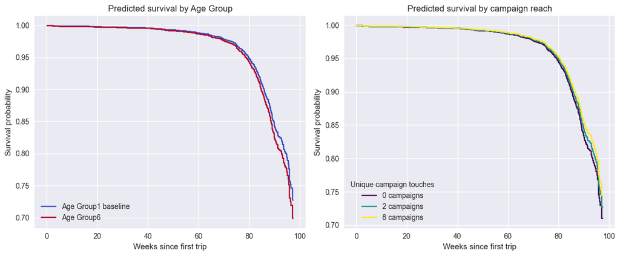

```python
campaign_percentiles = np.quantile(cox_df['unique_campaigns'], [0.1, 0.5, 0.9])
campaign_values = np.log1p(campaign_percentiles)
campaign_labels = [f"{int(round(val))} campaigns" for val in campaign_percentiles]

fig, axes = plt.subplots(1, 2, figsize=(12, 5))

cox.plot_partial_effects_on_outcome(
    covariates='demo1_Age Group6',
    values=[0, 1],
    plot_baseline=False,
    cmap='coolwarm',
    ax=axes[0],
)
axes[0].set_title('Predicted survival by Age Group')
axes[0].set_xlabel('Weeks since first trip')
axes[0].set_ylabel('Survival probability')
axes[0].legend(['Age Group1 baseline', 'Age Group6'])

cox.plot_partial_effects_on_outcome(
    covariates='log_unique_campaigns',
    values=campaign_values,
    plot_baseline=False,
    cmap='viridis',
    ax=axes[1],
)
axes[1].set_title('Predicted survival by campaign reach')
axes[1].set_xlabel('Weeks since first trip')
axes[1].set_ylabel('Survival probability')
axes[1].legend(campaign_labels, title='Unique campaign touches')

fig.tight_layout()
partial_path = OUTPUT_DIR / 'cox_partial_effects.png'
fig.savefig(partial_path, dpi=150)
print(f'Saved Cox partial effects plot to {partial_path}')
plt.show()
plt.close(fig)
```

Analysis takeaway:

1. Age cohorts: Holding spend and campaign activity constant, Age Group 6’s curve (red) drops slightly faster than the Age Group1 baseline (blue) once we get past ~70–80 weeks. The gap is only a few percentage points, but it mirrors the Cox coefficient where demo1_Age Group6 had a hazard ratio >1 while the Age Group1 baseline sat lower—older households (Group6) churn a bit sooner even after controlling for behavior.
2. Campaign reach: Varying the log-transformed unique campaign count barely moves the survival curves until the very end of the observation window. Households with 8 campaign touches (yellow) retain fractionally better than those with 0 touches (purple), but the spread is minimal, consistent with the insignificant log_unique_campaigns coefficient in the Cox summary. Campaign exposure alone doesn’t shift retention much once we already adjust for trips, spend, and coupons; the levers that matter most remain the behavioral ones.

Next steps:

- Design experiments that push low-engagement shoppers—especially Age Group6—toward their first coupon redemption or an extra trip, then re-run the Cox model on uplifted cohorts.
- Refresh the survival dataset monthly to monitor whether new campaigns actually shift the behavioral drivers (trips/spend) that reduce hazard.
- Enrich the model with recency or additional digital-touch metrics so we can detect campaign formats that change shopping cadence earlier.

#### ANNEX

##### Covariate reference

- `coupon_user_flag`: Indicator that the household redeemed at least one coupon.
- `campaign_reached_flag`: Indicator that the shopper appeared in the campaign table (touched by >=1 campaign).
- `log_unique_campaigns`: Log-transformed count of distinct campaigns received; keeps very high exposure from dominating the fit.
- `coupons_redeemed`: Raw count of redeemed coupons; complements the binary flag above.
- `trip_frequency_per_week`: Trips divided by observed weeks, capturing cadence independent of tenure length.
- `avg_trip_value`: Average basket value (total spend / trips), so a positive coefficient means larger tickets accelerate churn.
- `log_total_spend`: Log of cumulative spend during the observation window. The hazard ratio around 0.67 shows that heavier spenders churn more slowly.
- `coupon_share`: Share of spend funded by coupons (loyalty_discount_share); gauges dependence on discounts.
- `log_trips`: Log of number of trips. With a hazard ratio ≈0.57 it confirms that more trips materially lower churn risk.
- `demo1_Age Group2` … `demo1_Age Group6`: Dummy variables from `pd.get_dummies(demo_class_1, prefix='demo1', drop_first=True)`. `demo_class_1` is the age-based segmentation in the demographic table. Age Group1 is the omitted reference, so each dummy’s hazard ratio compares that segment against Age Group1 after controlling for the other covariates.

`demo_class_1` holds six ordered age clusters supplied by the retailer (Age Group1 through Age Group6). Because the names are abstract rather than explicit ages, we interpret them as relative cohorts—e.g., the significant `demo1_Age Group2` coefficient above means that the Age Group2 households show about a 42% lower hazard than the Age Group1 baseline, all else equal.